# R Notebook

sample(Hobby_Data)

## **Kids Hobby Prediction Dataset**

**Description:**

Following the selection of our data set (“Hobby_Data”) which predicts kids’ hobbies, that was collected by asking their parents specific questions about their kid’s preferences, capabilities, and achievements. To help us train the machine to predict the kid’s hobby. We will begin to preprocess and analyze the data.

**Attribute** **Description:**

| Attribute name | **Description** | **Data type** |
| --- | --- | --- |
| Olympiad_Participation | Has your child participated in any Science/Maths | Boolean |
| Scholarship | Has he/she received any scholarship? | Boolean |
| School | Love’s going to school? | Boolean |
| Fav_sub | What is his/her favorite subject? | Categorical |
| Projects | Has done any projects under academics before? | Boolean |
| Grasp_pow | His/Her Grasping power (1-6) | Ordinal |
| Time_sprt | How much time does he/she spend playing outdoor/indoor games? | Ordinal |
| Medals | Medals won in Sports? | Boolean |
| Career_sprt | Want’s to pursue his/her career in sports? | Boolean |
| Act_sprt | Regular in his/her sports activities? | Boolean |
| Fant_arts | Love creating fantasy paintings? | Boolean |
| Won_arts | Won art competitions? | Ordinal |
| Time_art | Time utilized in Arts? | Ordinal |
| Predicted Hobby | predictions for the hobby that the kid wouldl ike | Categorical |

**General information about the data set:**

```r
str(Hobby_Data)
```

```
tibble [1,601 × 14] (S3: tbl_df/tbl/data.frame)
 $ Olympiad_Participation: chr [1:1601] "Yes" "Yes" "Yes" "Yes" ...
 $ Scholarship           : chr [1:1601] "Yes" "Yes" "Yes" "Yes" ...
 $ School                : chr [1:1601] "Yes" "Yes" "Yes" "Yes" ...
 $ Fav_sub               : chr [1:1601] "Mathematics" "Mathematics" "Science" "Mathematics" ...
 $ Projects              : chr [1:1601] "Yes" "Yes" "Yes" "Yes" ...
 $ Grasp_pow             : num [1:1601] 5 3 5 5 5 6 3 5 3 5 ...
 $ Time_sprt             : num [1:1601] 1 2 1 1 3 2 5 2 2 3 ...
 $ Medals                : chr [1:1601] "Yes" "No" "Yes" "Yes" ...
 $ Career_sprt           : chr [1:1601] "No" "No" "No" "No" ...
 $ Act_sprt              : chr [1:1601] "No" "No" "No" "No" ...
 $ Fant_arts             : chr [1:1601] "No" "No" "No" "No" ...
 $ Won_arts              : chr [1:1601] "Maybe" "No" "No" "Maybe" ...
 $ Time_art              : num [1:1601] 3 1 1 3 2 4 2 3 1 1 ...
 $ Predicted Hobby       : chr [1:1601] "Academics" "Academics" "Academics" "Academics" ...
```

**summary of the dataset:**

- **samples of raw dataset:**

```r
sample(Hobby_Data)
```

| Time_art | Fant_arts | Grasp_pow | Projects | Career_sprt | Predicted Hobby | Won_arts | Fav_sub | Act_sprt | Time_sprt | School | Olympiad_Participation | Scholarship | Medals |
| --- | --- | --- | --- | --- | --- | --- | --- | --- | --- | --- | --- | --- | --- |
| 3 | No | 5 | Yes | No | Academics | Maybe | Mathematics | No | 1 | Yes | Yes | Yes | Yes |
| 1 | No | 3 | Yes | No | Academics | No | Mathematics | No | 2 | Yes | Yes | Yes | No |
| 1 | No | 5 | Yes | No | Academics | No | Science | No | 1 | Yes | Yes | Yes | Yes |
| 3 | No | 5 | Yes | No | Academics | Maybe | Mathematics | No | 1 | Yes | Yes | Yes | Yes |
| 2 | No | 5 | Yes | No | Academics | No | Science | No | 3 | Yes | Yes | Yes | No |
| 4 | No | 6 | Yes | No | Academics | No | Mathematics | No | 2 | Yes | Yes | Yes | Yes |
| 2 | No | 3 | Yes | No | Academics | No | Science | No | 5 | Yes | Yes | Yes | No |
| 3 | No | 5 | No | No | Academics | Maybe | Mathematics | No | 2 | Yes | Yes | Yes | No |
| 1 | No | 3 | Yes | No | Academics | No | Science | No | 2 | Yes | Yes | Yes | Yes |
| 1 | No | 5 | Yes | No | Academics | No | Science | No | 3 | Yes | Yes | Yes | Yes |

[output cut: 990 more lines]

- **variables distribution:**

  In our dataset, numeric variables are not available; instead, we have three ordinal variables. Due to the nature of our data types, certain types of graphs, such as scatter plots and box plots, were not suitable for our analysis.

```r
install.packages("magrittr") # install only one time then put this command as comment after installation
```

```
Error in install.packages : Updating loaded packages
```

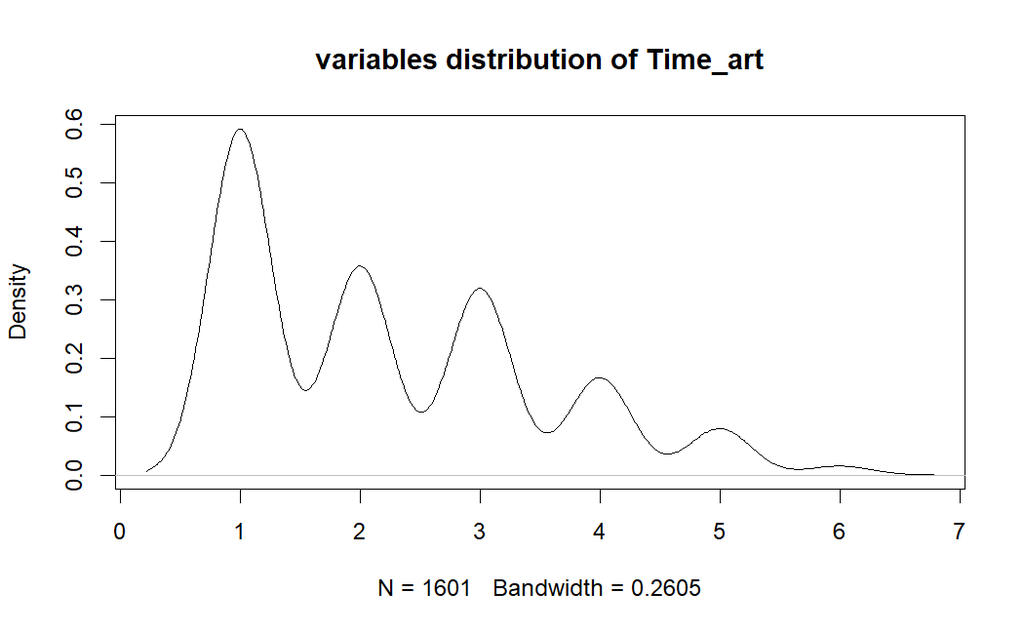

```r
library(magrittr) ## for pipe operations
Hobby_Data$Time_art %>% density() %>% plot(main='variables distribution of Time_art')
```

In the “Time_art” variable, parents were requested to assess the time their child dedicated to artistic pursuits like painting or paper crafting, using a scale ranging from 1 to 6, where 6 represents the highest level of involvement. It’s worth noting that the concentration of lower ratings at the lower end of the scale (1) is quite pronounced, and this tendency may be attributed to the inherent inclination of children towards physical activities.

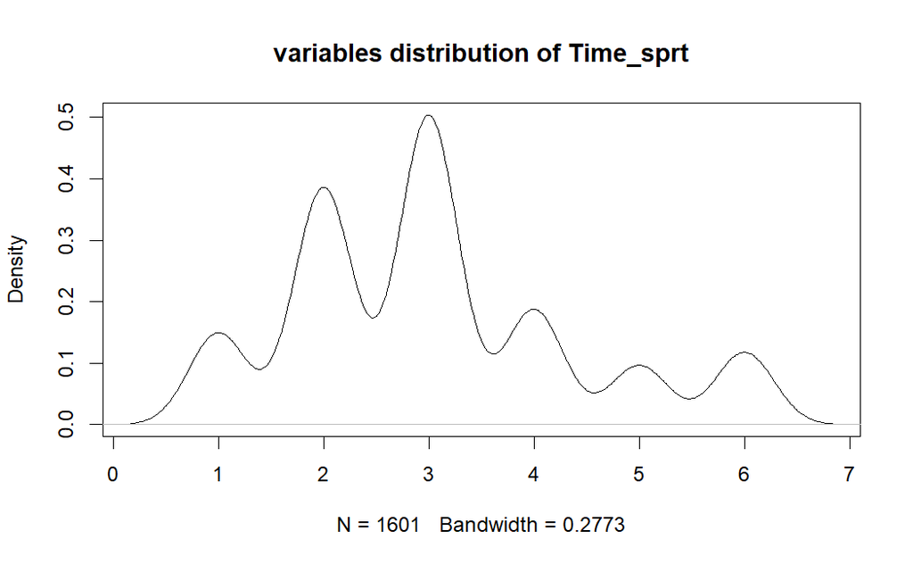

```r
Hobby_Data$Time_sprt %>% density() %>% plot(main='variables distribution of Time_sprt')
```

variables distribution of Grasp_pow:

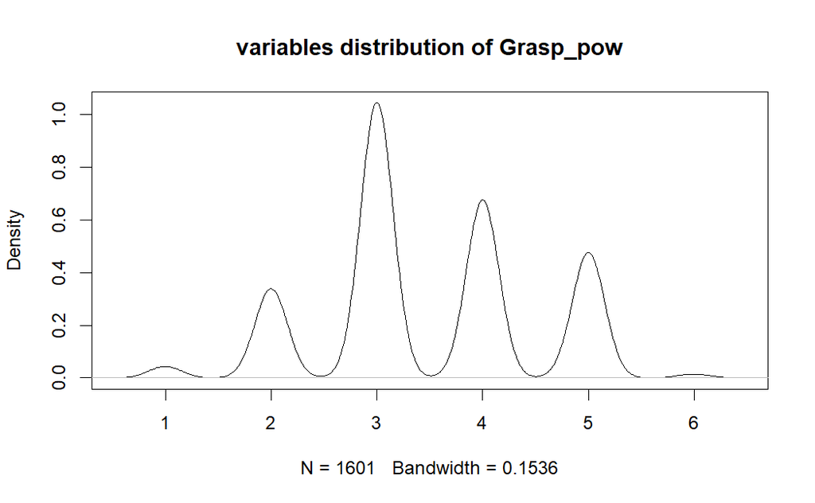

```r
Hobby_Data$Grasp_pow %>% density() %>% plot(main='variables distribution of Grasp_pow')
```

The density graph depicting parents’ ratings of their children’s grasp power, which ranges from 1 to 6, illustrates a trend where the most common rating is level 3, followed by level 4, level 5, level 2, level 1, and level 6. This distribution indicates that a substantial proportion of parents believe their children possess grasp power that is average or slightly above average (levels 3 and 4), with fewer children rated at the extremes (levels 1, 2, 5, and 6).

variables distribution of the class label ‘Predicted Hobby’:

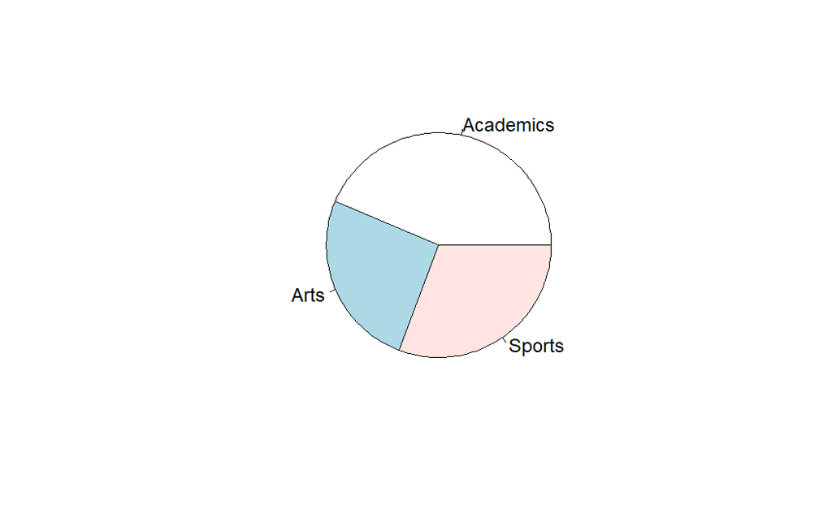

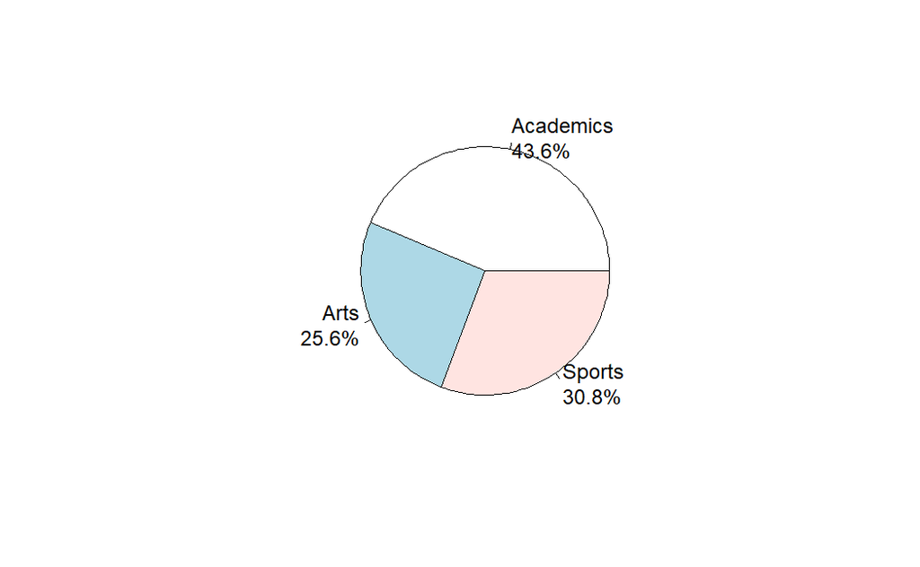

**#1# Data cleaning:**

During the data cleaning stage, finding and fixing faults, inconsistencies, and errors in a dataset helps it be more reliable and of higher quality for analysis and modeling. There are methods for handling missing values, detecting outliers, resolving inconsistencies, and standardizing formats.

import Dataset”Hobby_Data”

```r
setwd("/Users/96653/Documents/GitHub/KidsHobby/Dataset")



View(Hobby_Data)

str(Hobby_Data)
```

check missing value :

```r
is.na(Hobby_Data)
```

find the total null values in the dataset:

```r
sum(is.na(Hobby_Data))
```

```
[1] 0
```

We simply looked for missing values, and there are no missing values in the dataset. According to our investigation, the dataset does not contain any outliers since it doesn’t have a numerical data type. Additionally, there are no inconsistent values or other errors.

**#2#Encoding:**

Converting categorical or non-numeric data into a numerical format, which is necessary for compatibility with machine learning

```r
Hobby_Data$Olympiad_Participation = factor(Hobby_Data$Olympiad_Participation,levels = c("No", "Yes"), labels = c(0, 1))
Hobby_Data$Scholarship = factor(Hobby_Data$Scholarship , levels = c("No", "Yes"), labels = c(0, 1))
Hobby_Data$School = factor(Hobby_Data$School, levels = c("No", "Yes"), labels = c(0, 1))
Hobby_Data$Projects = factor(Hobby_Data$Projects, levels = c("No", "Yes"), labels = c(0, 1))
Hobby_Data$Medals = factor(Hobby_Data$Medals, levels = c("No", "Yes"), labels = c(0, 1))
Hobby_Data$Career_sprt = factor(Hobby_Data$Career_sprt, levels = c("No", "Yes"), labels = c(0, 1))
Hobby_Data$Act_sprt = factor(Hobby_Data$Act_sprt, levels = c("No", "Yes"), labels = c(0, 1))
Hobby_Data$Fant_arts = factor(Hobby_Data$Fant_arts, levels = c("No", "Yes"), labels = c(0, 1))
Hobby_Data$Won_arts = factor(Hobby_Data$Won_arts, levels = c("No", "Maybe", "Yes"), labels = c(0, 2, 1))
Hobby_Data$Fav_sub = factor(Hobby_Data$Fav_sub, levels = c("Science", "Mathematics", "History/Geography", "Any language"), labels = c(1, 2, 3, 4))
```

**Statistical measures :**

```r
find_mode <- function(x) {
  u <- unique(x)
  tab <- tabulate(match(x, u))
  u[tab == max(tab)]
}

find_mode(Hobby_Data$Time_art)
```

```
[1] 1
```

The histogram graph for “Time_art” variable

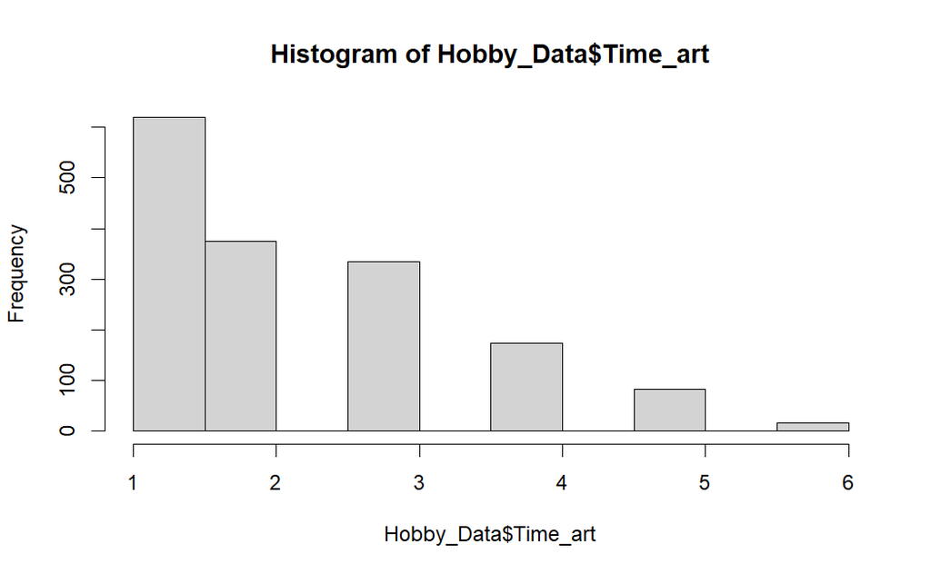

```r
hist(Hobby_Data$Time_art)
```

The histogram makes it evident that the mode is equal to 1, and we believe that the high frequency of parents ranking “1” as the most chosen rank in the “Time_art” variable could be attributed to several factors. It might indicate that a significant number of parents perceive their children’s involvement in art activities as relatively low, possibly due to time constraints, academic priorities, or a limited interest in art. Alternatively, it could reflect that parents value a more balanced approach to their children’s activities, with a variety of interests and responsibilities sharing their time. This trend could also result from a cultural or educational emphasis on other subjects and extracurricular activities that compete for a child’s time, potentially leading to a lower ranking for art-related activities.

```r
find_mode(Hobby_Data$Grasp_pow)
```

```
[1] 3
```

The histogram graph for “Grasp_pow” variable

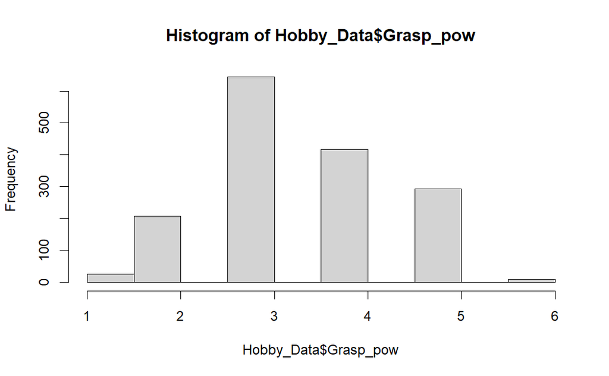

```r
hist(Hobby_Data$Grasp_pow)
```

Rank 3, in this context, may have been the most chosen rank because it likely represents an average or moderate level of grasp power. Parents may have assessed their children’s grasp power as neither exceptionally strong (rank 5 or 6) nor particularly weak (rank 1 or 2), resulting in the preference for the middle-ranking option. This choice could reflect a perception that their children’s grasp power falls within a typical or expected range, making it the most common rating.

```r
find_mode(Hobby_Data$Time_sprt)
```

```
[1] 3
```

The histogram graph for “Time_sprt” variable

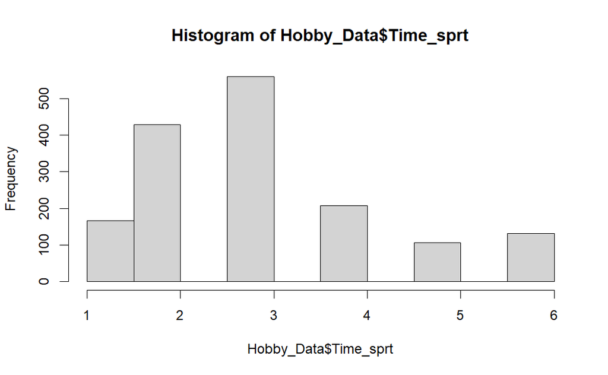

```r
hist(Hobby_Data$Time_sprt)
```

As shown in the histogram the rank 3 on a scale of 1 to 6 was likely the most chosen rank for assessing children’s involvement in sports because it represents a balanced middle ground. Parents may have perceived rank 3 as indicating that their children are moderately involved in sports, not excessively committed or disinterested. This middle-of-the-road ranking reflects a common perspective that many parents may hold, considering that extreme rankings, such as 1 or 6, might suggest either a lack of involvement or an excessive focus on sports, which may not align with their perception of their child’s overall well-rounded development.

**#3# Normalization and Discetization:**

We don’t need to use normalization and discetization in our dataset. Since our dataset doesn’t have numeric attributes and normalization involves mathematical operations, which can result in meaningless values and errors, Also, applying discretization leads to a loss of information and creates intervals and relationships that don’t exist between values.

**#4#Feature Selection:**

To improve the accuracy of our predictions for the target class “Predicted Hobby” and decrease the processing time of our classifier, we will utilize feature selection techniques. These techniques enable us to eliminate redundant or irrelevant attributes from the dataset, resulting in a more concise subset of features that provide the most valuable information for our predictions.

Specifically, we will use two feature selection methods: Rank Features by Importance and Feature Selection Using Recursive Feature Elimination (RFE).

1. **Rank Features by Importance:**

This method used in the code helps us determine which features are most important for predicting the “Predicted Hobby” class label in the dataset. It utilizes the Random Forest algorithm, known for its accurate prediction capabilities. This method calculates the importance of each feature by assessing its contribution to the overall accuracy of the predictions. By ranking the features based on their importance, we can identify the ones that have the greatest influence on determining hobbies.

Ensure the results are repeatable by setting a seed:

```r
set.seed(7)
```

Load the necessary libraries:

```r
library(randomForest)
```

Convert the class label to a factor:

```r
Hobby_Data$`Predicted Hobby` <- as.factor(Hobby_Data$`Predicted Hobby`)
```

Separate the predictors and the class label:

```r
predictors <- Hobby_Data[, -14]  # Excluding the class label (Predicted Hobby)
class_label <- Hobby_Data$`Predicted Hobby`
```

Train a Random Forest model:

```r
model <- randomForest(predictors, class_label, importance = TRUE)
```

Get the variable importance:

```r
importance <- importance(model)
```

Rank the features by importance:

```r
ranked_features <- sort(importance[, "MeanDecreaseGini"], decreasing = TRUE)
```

Print the ranked features:

```r
print(ranked_features)
```

```
           Career_sprt               Won_arts Olympiad_Participation
             244.51652              157.20844              106.70396
             Fant_arts               Time_art            Scholarship
             101.91931               88.02790               73.51776
              Act_sprt              Grasp_pow              Time_sprt
              53.85129               42.48783               36.40636
               Fav_sub                 School                 Medals
              24.05871               23.11827               16.80252
              Projects
              12.46063
```

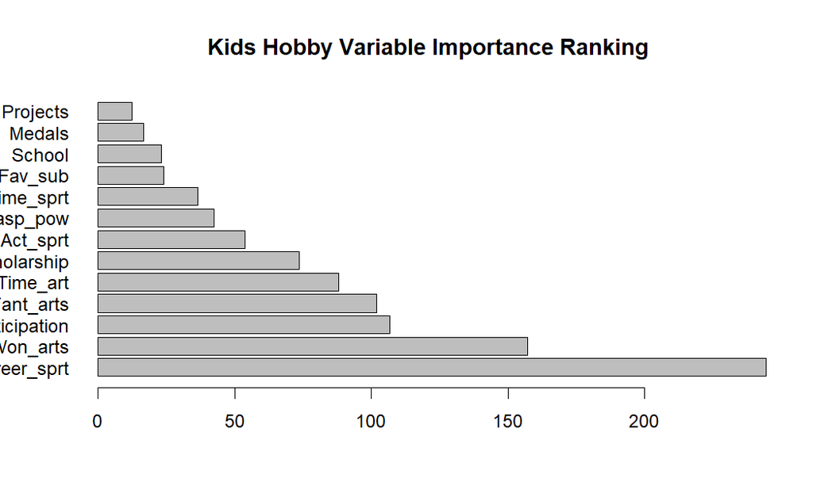

```r
barplot(ranked_features, horiz = TRUE, las = 1, main = "Kids Hobby Variable Importance Ranking")
```

2. **Feature Selection Using RFE:**

The Recursive Feature Elimination (RFE) method with Random Forest is a technique used to select the most important features for accurate predictions . It iteratively eliminates less relevant features, retraining the model at each step to evaluate performance. By focusing on the most informative features, RFE improves reduces complexity, and enhances prediction accuracy. It is particularly effective with Random Forest due to its ability to handle complex relationships and high-dimensional data. RFE helps identify the most important attributes associated with the target variable, enabling the creation of more efficient and accurate models.

Ensure the results are repeatable by setting a seed:

```r
set.seed(7)
```

Load the necessary libraries:

```r
library(caret)
```

Define the control parameters for RFE using random forest selection function:

```r
control <- rfeControl(functions = rfFuncs, method = "cv", number = 10)
```

Extract the predictor variables from Hobby_Data:

```r
predictors <- Hobby_Data[, -ncol(Hobby_Data)]
```

Convert the outcome variable to a factor:

```r
outcome <- as.factor(Hobby_Data$`Predicted Hobby`)
```

Run the RFE algorithm:

```r
results <- rfe(predictors, outcome, sizes = 1:ncol(Hobby_Data), rfeControl = control)
```

Summarize the results:

```r
print(results)
```

```
Recursive feature selection

Outer resampling method: Cross-Validated (10 fold)

Resampling performance over subset size:
```

|  | Variables | Accuracy | Kappa | AccuracySD | KappaSD | Selected |
| --- | --- | --- | --- | --- | --- | --- |
| 1 | 1 | 0.6996 | 0.5086 | 0.01698 | 0.02960 |  |
| 2 | 2 | 0.8488 | 0.7671 | 0.02773 | 0.04559 |  |
| 3 | 3 | 0.8763 | 0.8095 | 0.01483 | 0.02236 |  |
| 4 | 4 | 0.9019 | 0.8486 | 0.01918 | 0.02954 |  |
| 5 | 5 | 0.9094 | 0.8599 | 0.02386 | 0.03725 |  |
| 6 | 6 | 0.9119 | 0.8640 | 0.01825 | 0.02837 |  |
| 7 | 7 | 0.9213 | 0.8784 | 0.02069 | 0.03223 |  |
| 8 | 8 | 0.9238 | 0.8822 | 0.02336 | 0.03643 |  |
| 9 | 9 | 0.9250 | 0.8842 | 0.01845 | 0.02874 |  |
| 10 | 10 | 0.9288 | 0.8900 | 0.02049 | 0.03187 |  |

[output cut: 3 more lines]

```
The top 5 variables (out of 13):
   Career_sprt, Won_arts, Time_art, Fant_arts, Olympiad_Participation
```

List the chosen features selected by RFE:

```r
predictors(results)
```

```
 [1] "Career_sprt"            "Won_arts"               "Time_art"
 [4] "Fant_arts"              "Olympiad_Participation" "Scholarship"
 [7] "Act_sprt"               "Grasp_pow"              "Time_sprt"
[10] "School"                 "Medals"                 "Projects"
[13] "Fav_sub"
```

Plot the results:

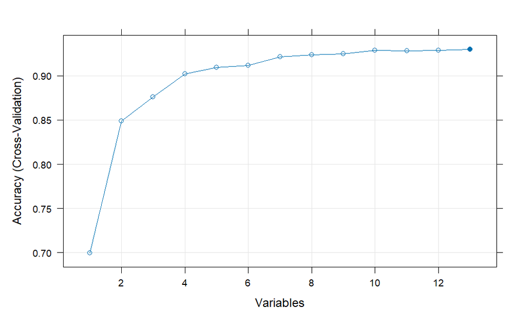

```r
plot(results, type = c("g", "o"))
```

Remove the specified columns from the Hobby_Kids dataset:

```r
Hobby_Data <- Hobby_Data[, !(colnames(Hobby_Data) %in% c("School", "Medals"))]
```

Display the updated dataset after deleting columns:

```r
View(Hobby_Data)
```

we can see that the two columns are deleted